# Biostatistics III in R

Code by Annika Tillander, Andreas Karlsson and Mark Clements

# Exercise 10. Examining the proportional hazards hypothesis (localised melanoma)

You may have to install the required packages the first time you use them. You can install a package by `install.packages("package_of_interest")` for each package you require.

```r
library(biostat3)
library(bshazard)
library(car)      # car::linearHypothesis -> biostat3::lincom
library(tinyplot) # plt()
```

Load melanoma data and explore it.

```r
localised <-
    subset(biostat3::melanoma, stage == "Localised") |>
    transform(death_cancer = ifelse( status == "Dead: cancer" & surv_mm <= 120, 1, 0), #censoring for > 120 months
           trunc_yy = pmin(surv_mm/12,10))  #scale to years and truncate to 10 years
```

## (a)

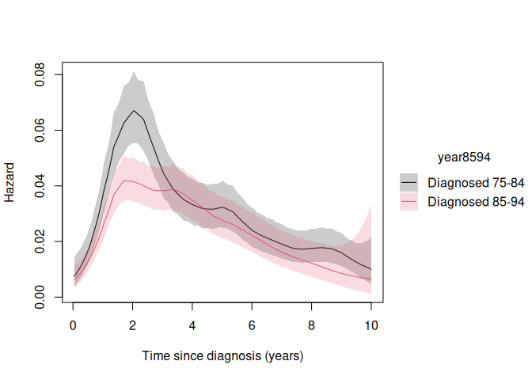

```r
# Using bshazard to smooth the Kaplan-Meier hazards by strata
hazDiaDate <- lapply(levels(localised$year8594),
                     function(level) bshazard(Surv(trunc_yy,death_cancer)~1, v=F,
                                              data=subset(localised, year8594==level)) |>
                                     with(data.frame(time,hazard,lower.ci,upper.ci,
                                                     year8594=level))) |>
    do.call(what=rbind)

## Comparing hazards
with(hazDiaDate, plt(hazard~time|year8594, ymin=lower.ci, ymax=upper.ci,
                     group=year8594,
                     type="ribbon",
                     xlab="Time since diagnosis (years)",
                     ylab="Hazard"))
```

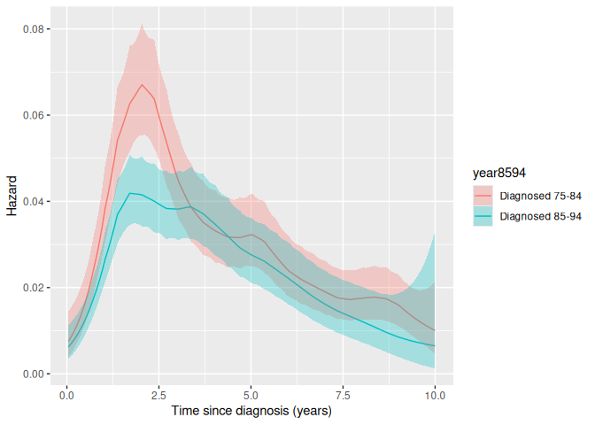

```r
# or using ggplot2
library(ggplot2)
ggplot(hazDiaDate, aes(x=time, y=hazard, fill=year8594,
                       ymin=lower.ci, ymax=upper.ci)) +
    geom_line(aes(color=year8594)) +
    geom_ribbon(alpha=0.3) +
    xlab("Time since diagnosis (years)") +
    ylab("Hazard")
```

## (b)

There is no strong evidence against an assumption of proportional hazards since we see (close to) parallel curves when plotting the instantaneous cause-specific hazard on the log scale.

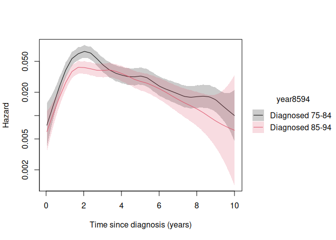

```r
## Comparing hazards on a log scales
with(hazDiaDate, plt(hazard~time|year8594, ymin=lower.ci, ymax=upper.ci,
                     group=year8594,
                     log="y",
                     type="ribbon",
                     xlab="Time since diagnosis (years)",
                     ylab="Hazard"))
```

## (c)

If the proportional hazards assumption is appropriate then we should see parallel lines. This looks okay; we shouldn’t put too much weight on the fact that the curves cross early in the follow-up since there are so few deaths there. The difference between the two log-cumulative hazard curves is similar during the part of the follow-up where we have the most information (most deaths). Note that these curves are not based on the estimated Cox model (i.e., they are unadjusted).

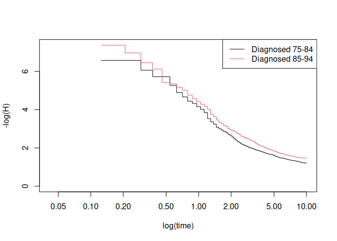

```r
survfit1 <- survfit(Surv(trunc_yy,death_cancer)~year8594, data=localised)
plot(survfit1, col=1:2, fun=function(S) -log(-log(S)), log="x",
     xlab="log(time)", ylab="-log(H)")
legend("topright",legend=levels(localised$year8594),col=1:2,lty=1)
```

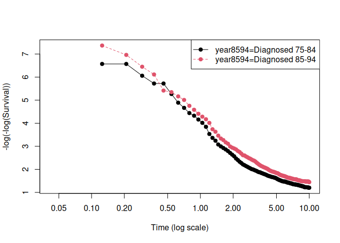

```r
## or we can use
biostat3::survPHplot(Surv(trunc_yy,death_cancer)~year8594, data=localised)
```

## (d)

The estimated hazard ratio from the Cox model is $0.78$ which is similar (as it should be) to the estimate made by looking at the hazard function plot.

```r
# Cox regression with time-since-entry as the timescale
# Note that R uses the Efron method for approximating the likelihood in the presence of ties
# whereas Stata (and some other software) use the Breslow method
cox1 <- coxph(Surv(trunc_yy, death_cancer==1) ~ year8594, data=localised)
summary(cox1)
```

```
## Call:
## coxph(formula = Surv(trunc_yy, death_cancer == 1) ~ year8594,
##     data = localised)
##
##   n= 5318, number of events= 960
##
##                             coef exp(coef) se(coef)      z Pr(>|z|)
## year8594Diagnosed 85-94 -0.25297   0.77649  0.06579 -3.845 0.000121 ***
## ---
## Signif. codes:  0 '***' 0.001 '**' 0.01 '*' 0.05 '.' 0.1 ' ' 1
##
##                         exp(coef) exp(-coef) lower .95 upper .95
## year8594Diagnosed 85-94    0.7765      1.288    0.6825    0.8834
##
## Concordance= 0.533  (se = 0.008 )
## Likelihood ratio test= 14.83  on 1 df,   p=1e-04
## Wald test            = 14.78  on 1 df,   p=1e-04
## Score (logrank) test = 14.86  on 1 df,   p=1e-04
```

## (e)

The plot of the scaled Schoenfeld residuals for the effect of period. Under proportional hazards, the smoother will be a horizontal line. The line does vary (with possibly an increasing log hazard ratio at around 4 years), but not in a linear pattern, which is consistent with the p-value of 0.10 for linear trend.

```r
cox2 <- coxph(Surv(trunc_yy, death_cancer==1) ~ sex + year8594 + agegrp, data=localised)
summary(cox2)
```

```
## Call:
## coxph(formula = Surv(trunc_yy, death_cancer == 1) ~ sex + year8594 +
##     agegrp, data = localised)
##
##   n= 5318, number of events= 960
##
##                             coef exp(coef) se(coef)      z Pr(>|z|)
## sexFemale               -0.53061   0.58825  0.06545 -8.107 5.19e-16 ***
## year8594Diagnosed 85-94 -0.33339   0.71649  0.06618 -5.037 4.72e-07 ***
## agegrp45-59              0.28283   1.32688  0.09417  3.003  0.00267 **
## agegrp60-74              0.62006   1.85904  0.09088  6.823 8.90e-12 ***
## agegrp75+                1.21801   3.38045  0.10443 11.663  < 2e-16 ***
## ---
## Signif. codes:  0 '***' 0.001 '**' 0.01 '*' 0.05 '.' 0.1 ' ' 1
##
##                         exp(coef) exp(-coef) lower .95 upper .95
## sexFemale                  0.5882     1.7000    0.5174    0.6688
## year8594Diagnosed 85-94    0.7165     1.3957    0.6293    0.8157
## agegrp45-59                1.3269     0.7536    1.1032    1.5959
## agegrp60-74                1.8590     0.5379    1.5557    2.2215
## agegrp75+                  3.3804     0.2958    2.7547    4.1483
##
## Concordance= 0.646  (se = 0.009 )
## Likelihood ratio test= 212.7  on 5 df,   p=<2e-16
## Wald test            = 217.9  on 5 df,   p=<2e-16
## Score (logrank) test = 226.8  on 5 df,   p=<2e-16
```

```r
## Plot of the scaled Schoenfeld residuals for calendar period 1985–94.
## The smooth line shows the estimated log hazard ratio as a function of time.
cox2.phtest <- cox.zph(cox2, terms=FALSE) # for separate plots
print(cox2.phtest)
```

```
##                          chisq df       p
## sexFemale                0.823  1 0.36431
## year8594Diagnosed 85-94  2.632  1 0.10471
## agegrp45-59              0.860  1 0.35365
## agegrp60-74              0.855  1 0.35508
## agegrp75+               10.502  1 0.00119
## GLOBAL                  22.247  5 0.00047
```

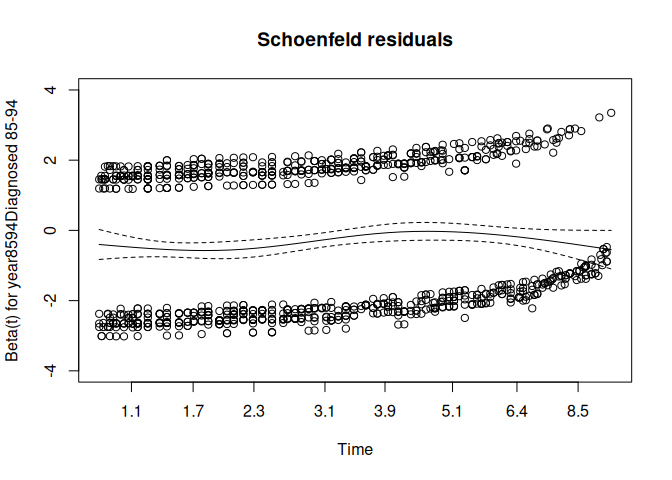

```r
plot(cox2.phtest,var=2,resid=TRUE, se=TRUE, main="Schoenfeld residuals", ylim=c(-4,4))
```

## (f)

Based on the tests for linear trends, we expect a trend for the log hazard ratio comparing ages less than 45 years with those aged 75 years and over. All three log hazard ratios tend to decrease by time of diagnosis, while the trend is more marked for the oldest age group (75+). There is evidence for non-proportionality, particularly for those patients aged 75 years and over.

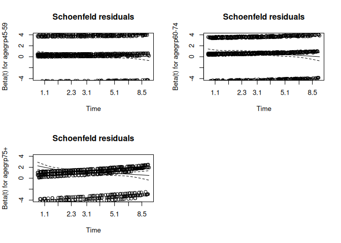

```r
par(mfrow=c(2,2))
for (var in 3:5)
    plot(cox2.phtest,var=var,resid=TRUE, se=TRUE, main="Schoenfeld residuals", ylim=c(-4,4))
```

## (g)

It seems that there is evidence of non-proportional hazards by age (particularly for the comparison of the oldest to youngest) but not for calendar period. The plot of Schoenfeld residuals suggested non-proportionality for period but this was not statistically significant.

```r
## The results from the previous proportional hazards assumption test
print(cox.zph(cox2))
```

```
##           chisq df       p
## sex       0.823  1 0.36431
## year8594  2.632  1 0.10471
## agegrp   16.858  3 0.00076
## GLOBAL   22.247  5 0.00047
```

## (h)

The hazard ratios for age in the top panel are for the first two years subsequent to diagnosis. To obtain the hazard ratios for the period two years or more following diagnosis we multiply the hazard ratios in the top and bottom panel. That is, during the first two years following diagnosis patients aged 75 years or more at diagnosis have 5.4 times higher cancer-specific mortality than patients aged 0–44 at diagnosis. During the period two years or more following diagnosis the corresponding hazard ratio is $5.4 \times 0.49=2.66$.  
Using `survSplit` to split on time will give you the same results as above. We see that the age:follow up interaction is statistically significant.

```r
melanoma2p8Split <- survSplit(localised, cut=c(2), end="trunc_yy", start="start",
                              event="death_cancer", episode="fu") |>
    transform(fu = as.factor(fu))

##Tabulate ageband including risk_time
melanoma2p8Split |> subset(id<=3, select=c(id, start, trunc_yy))
```

```
##   id start  trunc_yy
## 1  1     0  2.000000
## 2  1     2  2.208333
## 3  2     0  2.000000
## 4  2     2  4.625000
## 5  3     0  2.000000
## 6  3     2 10.000000
```

```r
head(melanoma2p8Split)
```

```
##      sex age     stage mmdx yydx surv_mm surv_yy      status       subsite        year8594
## 1 Female  81 Localised    2 1981    26.5     2.5 Dead: other Head and Neck Diagnosed 75-84
## 2 Female  81 Localised    2 1981    26.5     2.5 Dead: other Head and Neck Diagnosed 75-84
## 3 Female  75 Localised    9 1975    55.5     4.5 Dead: other Head and Neck Diagnosed 75-84
## 4 Female  75 Localised    9 1975    55.5     4.5 Dead: other Head and Neck Diagnosed 75-84
## 5 Female  78 Localised    2 1978   177.5    14.5 Dead: other         Limbs Diagnosed 75-84
## 6 Female  78 Localised    2 1978   177.5    14.5 Dead: other         Limbs Diagnosed 75-84
##           dx       exit agegrp id      ydx    yexit start  trunc_yy death_cancer fu
## 1 1981-02-02 1983-04-20    75+  1 1981.088 1983.298     0  2.000000            0  1
## 2 1981-02-02 1983-04-20    75+  1 1981.088 1983.298     2  2.208333            0  2
## 3 1975-09-21 1980-05-07    75+  2 1975.720 1980.348     0  2.000000            0  1
## 4 1975-09-21 1980-05-07    75+  2 1975.720 1980.348     2  4.625000            0  2
## 5 1978-02-21 1992-12-07    75+  3 1978.140 1992.934     0  2.000000            0  1
## 6 1978-02-21 1992-12-07    75+  3 1978.140 1992.934     2 10.000000            0  2
```

```r
cox2p8Split1 <- coxph(Surv(start, trunc_yy, death_cancer) ~ sex + year8594 + agegrp*fu,
                      data=melanoma2p8Split)
summary(cox2p8Split1)
```

```
## Call:
## coxph(formula = Surv(start, trunc_yy, death_cancer) ~ sex + year8594 +
##     agegrp * fu, data = melanoma2p8Split)
##
##   n= 9856, number of events= 960
##
##                             coef exp(coef) se(coef)      z Pr(>|z|)
## sexFemale               -0.52742   0.59012  0.06543 -8.061 7.58e-16 ***
## year8594Diagnosed 85-94 -0.33548   0.71499  0.06623 -5.065 4.08e-07 ***
## agegrp45-59              0.53058   1.69992  0.19634  2.702  0.00689 **
## agegrp60-74              0.90046   2.46074  0.18741  4.805 1.55e-06 ***
## agegrp75+                1.68918   5.41503  0.19175  8.809  < 2e-16 ***
## fu2                           NA        NA  0.00000     NA       NA
## agegrp45-59:fu2         -0.32093   0.72547  0.22382 -1.434  0.15161
## agegrp60-74:fu2         -0.36715   0.69270  0.21467 -1.710  0.08720 .
## agegrp75+:fu2           -0.70783   0.49271  0.23207 -3.050  0.00229 **
## ---
## Signif. codes:  0 '***' 0.001 '**' 0.01 '*' 0.05 '.' 0.1 ' ' 1
##
##                         exp(coef) exp(-coef) lower .95 upper .95
## sexFemale                  0.5901     1.6946    0.5191    0.6709
## year8594Diagnosed 85-94    0.7150     1.3986    0.6280    0.8141
## agegrp45-59                1.6999     0.5883    1.1569    2.4978
## agegrp60-74                2.4607     0.4064    1.7043    3.5529
## agegrp75+                  5.4150     0.1847    3.7186    7.8853
## fu2                            NA         NA        NA        NA
## agegrp45-59:fu2            0.7255     1.3784    0.4678    1.1250
## agegrp60-74:fu2            0.6927     1.4436    0.4548    1.0550
## agegrp75+:fu2              0.4927     2.0296    0.3126    0.7765
##
## Concordance= 0.645  (se = 0.009 )
## Likelihood ratio test= 222.5  on 8 df,   p=<2e-16
## Wald test            = 224.5  on 8 df,   p=<2e-16
## Score (logrank) test = 238  on 8 df,   p=<2e-16
```

```r
cox2p8Split1b <- coxph(Surv(start, trunc_yy, death_cancer) ~ sex + year8594 + agegrp +
                           I(agegrp=="45-59" & fu=="2") + I(agegrp=="60-74" & fu=="2") +
                           I(agegrp=="75+" & fu=="2"), data=melanoma2p8Split)
summary(cox2p8Split1b)
```

```
## Call:
## coxph(formula = Surv(start, trunc_yy, death_cancer) ~ sex + year8594 +
##     agegrp + I(agegrp == "45-59" & fu == "2") + I(agegrp == "60-74" &
##     fu == "2") + I(agegrp == "75+" & fu == "2"), data = melanoma2p8Split)
##
##   n= 9856, number of events= 960
##
##                                          coef exp(coef) se(coef)      z Pr(>|z|)
## sexFemale                            -0.52742   0.59012  0.06543 -8.061 7.58e-16 ***
## year8594Diagnosed 85-94              -0.33548   0.71499  0.06623 -5.065 4.08e-07 ***
## agegrp45-59                           0.53058   1.69992  0.19634  2.702  0.00689 **
## agegrp60-74                           0.90046   2.46074  0.18741  4.805 1.55e-06 ***
## agegrp75+                             1.68918   5.41503  0.19175  8.809  < 2e-16 ***
## I(agegrp == "45-59" & fu == "2")TRUE -0.32093   0.72547  0.22382 -1.434  0.15161
## I(agegrp == "60-74" & fu == "2")TRUE -0.36715   0.69270  0.21467 -1.710  0.08720 .
## I(agegrp == "75+" & fu == "2")TRUE   -0.70783   0.49271  0.23207 -3.050  0.00229 **
## ---
## Signif. codes:  0 '***' 0.001 '**' 0.01 '*' 0.05 '.' 0.1 ' ' 1
##
##                                      exp(coef) exp(-coef) lower .95 upper .95
## sexFemale                               0.5901     1.6946    0.5191    0.6709
## year8594Diagnosed 85-94                 0.7150     1.3986    0.6280    0.8141
## agegrp45-59                             1.6999     0.5883    1.1569    2.4978
## agegrp60-74                             2.4607     0.4064    1.7043    3.5529
## agegrp75+                               5.4150     0.1847    3.7186    7.8853
## I(agegrp == "45-59" & fu == "2")TRUE    0.7255     1.3784    0.4678    1.1250
## I(agegrp == "60-74" & fu == "2")TRUE    0.6927     1.4436    0.4548    1.0550
## I(agegrp == "75+" & fu == "2")TRUE      0.4927     2.0296    0.3126    0.7765
##
## Concordance= 0.645  (se = 0.009 )
## Likelihood ratio test= 222.5  on 8 df,   p=<2e-16
## Wald test            = 224.5  on 8 df,   p=<2e-16
## Score (logrank) test = 238  on 8 df,   p=<2e-16
```

The regression equation for the cox2p8Split1 model is
$$\begin{align*}
h(t|\text{year8594},\text{sex},\text{agegrp},\text{fu}) &= h_0(t)
\exp(\beta_1 I(\text{sex}=\text{"Female"})+\beta_2
I(\text{year8594}=\text{"Diagnosed 85-94"})+\\
&\qquad\beta_3 I(\text{agegrp}=\text{"45-59"})+\beta_4
I(\text{agegrp}=\text{"60-74"})+\beta_5
I(\text{agegrp}=\text{"75+"}) + \\
&\qquad \beta_6 I(\text{agegrp}=\text{"45-59"} \&\
\text{fu}=2)+\beta_7 I(\text{agegrp}=\text{"60-74"} \&\
\text{fu}=2)+\beta_8 I(\text{agegrp}=\text{"75+"} \&\
\text{fu}=2))
\end{align*}$$
where $h(t|\text{year8594},\text{sex},\text{agegrp},\text{fu})$ is the hazard at time $t$ given covariates $\text{year8594}$, $\text{sex}$, $\text{agegrp}$ and $\text{fu}$, with baseline hazard $h_0(t)$ and regression coefficients representing log hazard ratios for $\beta_1$ for females, $\beta_2$ for the calendar period 1985–1994, $\beta_3$ for those aged 45–59 years at diagnosis, $\beta_4$ for those aged 60–74 years and $\beta_5$ for those aged 75 years and over, with interaction terms for the change in log hazard ratio for the second follow-up period being $\beta_6$ for those aged 45–59 years at diagnosis, $\beta_7$ for those aged 60–74 years and $\beta_8$ for those aged 75 years and over.

## (i)

|  | 0–2 years | 2+ years |
| --- | --- | --- |
| Agegrp0-44 | 1.00 | 1.00 |
| Agegrp45-59 | 1.70 | 1.23 |
| Agegrp60-74 | 2.46 | 1.70 |
| Agegrp75+ | 5.42 | 2.67 |

```r
cox2p8Split2 <- coxph(Surv(start, trunc_yy, death_cancer) ~ sex + year8594 + fu +
                          fu:agegrp, data=melanoma2p8Split)
summary(cox2p8Split2)
```

```
## Call:
## coxph(formula = Surv(start, trunc_yy, death_cancer) ~ sex + year8594 +
##     fu + fu:agegrp, data = melanoma2p8Split)
##
##   n= 9856, number of events= 960
##
##                             coef exp(coef) se(coef)      z Pr(>|z|)
## sexFemale               -0.52742   0.59012  0.06543 -8.061 7.58e-16 ***
## year8594Diagnosed 85-94 -0.33548   0.71499  0.06623 -5.065 4.08e-07 ***
## fu2                           NA        NA  0.00000     NA       NA
## fu1:agegrp45-59          0.53058   1.69992  0.19634  2.702  0.00689 **
## fu2:agegrp45-59          0.20965   1.23325  0.10774  1.946  0.05167 .
## fu1:agegrp60-74          0.90046   2.46074  0.18741  4.805 1.55e-06 ***
## fu2:agegrp60-74          0.53331   1.70456  0.10479  5.089 3.59e-07 ***
## fu1:agegrp75+            1.68918   5.41503  0.19175  8.809  < 2e-16 ***
## fu2:agegrp75+            0.98135   2.66806  0.13157  7.458 8.75e-14 ***
## ---
## Signif. codes:  0 '***' 0.001 '**' 0.01 '*' 0.05 '.' 0.1 ' ' 1
##
##                         exp(coef) exp(-coef) lower .95 upper .95
## sexFemale                  0.5901     1.6946    0.5191    0.6709
## year8594Diagnosed 85-94    0.7150     1.3986    0.6280    0.8141
## fu2                            NA         NA        NA        NA
## fu1:agegrp45-59            1.6999     0.5883    1.1569    2.4978
## fu2:agegrp45-59            1.2332     0.8109    0.9985    1.5232
## fu1:agegrp60-74            2.4607     0.4064    1.7043    3.5529
## fu2:agegrp60-74            1.7046     0.5867    1.3881    2.0932
## fu1:agegrp75+              5.4150     0.1847    3.7186    7.8853
## fu2:agegrp75+              2.6681     0.3748    2.0616    3.4530
##
## Concordance= 0.645  (se = 0.009 )
## Likelihood ratio test= 222.5  on 8 df,   p=<2e-16
## Wald test            = 224.5  on 8 df,   p=<2e-16
## Score (logrank) test = 238  on 8 df,   p=<2e-16
```

We can also use the `tt` argument in `coxph` for modelling for time-varying effects:

```r
## Alternative approach using tt():
## http://cran.r-project.org/web/packages/survival/vignettes/timedep.pdf
cox2p8tvc2 <- coxph(Surv(trunc_yy, death_cancer) ~ sex + year8594 + agegrp +
                        tt(agegrp=="45-59") + tt(agegrp=="60-74") + tt(agegrp=="75+"),
                    data=localised,
                    tt = function(x, t, ...) x*(t>=2))
summary(cox2p8tvc2)
```

```
## Call:
## coxph(formula = Surv(trunc_yy, death_cancer) ~ sex + year8594 +
##     agegrp + tt(agegrp == "45-59") + tt(agegrp == "60-74") +
##     tt(agegrp == "75+"), data = localised, tt = function(x, t,
##     ...) x * (t >= 2))
##
##   n= 5318, number of events= 960
##
##                             coef exp(coef) se(coef)      z Pr(>|z|)
## sexFemale               -0.52742   0.59012  0.06543 -8.061 7.58e-16 ***
## year8594Diagnosed 85-94 -0.33548   0.71499  0.06623 -5.065 4.08e-07 ***
## agegrp45-59              0.53058   1.69992  0.19634  2.702  0.00689 **
## agegrp60-74              0.90046   2.46074  0.18741  4.805 1.55e-06 ***
## agegrp75+                1.68918   5.41503  0.19175  8.809  < 2e-16 ***
## tt(agegrp == "45-59")   -0.32093   0.72547  0.22382 -1.434  0.15161
## tt(agegrp == "60-74")   -0.36715   0.69270  0.21467 -1.710  0.08720 .
## tt(agegrp == "75+")     -0.70783   0.49271  0.23207 -3.050  0.00229 **
## ---
## Signif. codes:  0 '***' 0.001 '**' 0.01 '*' 0.05 '.' 0.1 ' ' 1
##
##                         exp(coef) exp(-coef) lower .95 upper .95
## sexFemale                  0.5901     1.6946    0.5191    0.6709
## year8594Diagnosed 85-94    0.7150     1.3986    0.6280    0.8141
## agegrp45-59                1.6999     0.5883    1.1569    2.4978
## agegrp60-74                2.4607     0.4064    1.7043    3.5529
## agegrp75+                  5.4150     0.1847    3.7186    7.8853
## tt(agegrp == "45-59")      0.7255     1.3784    0.4678    1.1250
## tt(agegrp == "60-74")      0.6927     1.4436    0.4548    1.0550
## tt(agegrp == "75+")        0.4927     2.0296    0.3126    0.7765
##
## Concordance= 0.645  (se = 0.009 )
## Likelihood ratio test= 222.5  on 8 df,   p=<2e-16
## Wald test            = 224.5  on 8 df,   p=<2e-16
## Score (logrank) test = 238  on 8 df,   p=<2e-16
```

```r
## The tt labels do not play nicely with lincom:(

cox2p8tvct <- coxph(Surv(trunc_yy, death_cancer) ~ sex + year8594 + agegrp + tt(agegrp),
                    data=localised,
                    tt = function(x, t, ...) cbind(`45-59`=(x=="45-59")*t,
                                                   `60-74`=(x=="60-74")*t,
                                                   `75+`=(x=="75+")*t))
summary(cox2p8tvct)
```

```
## Call:
## coxph(formula = Surv(trunc_yy, death_cancer) ~ sex + year8594 +
##     agegrp + tt(agegrp), data = localised, tt = function(x, t,
##     ...) cbind(`45-59` = (x == "45-59") * t, `60-74` = (x ==
##     "60-74") * t, `75+` = (x == "75+") * t))
##
##   n= 5318, number of events= 960
##
##                             coef exp(coef) se(coef)      z Pr(>|z|)
## sexFemale               -0.52429   0.59198  0.06541 -8.016 1.10e-15 ***
## year8594Diagnosed 85-94 -0.33768   0.71342  0.06627 -5.095 3.48e-07 ***
## agegrp45-59              0.49614   1.64237  0.18573  2.671 0.007555 **
## agegrp60-74              0.99490   2.70445  0.17856  5.572 2.52e-08 ***
## agegrp75+                1.89383   6.64478  0.20455  9.259  < 2e-16 ***
## tt(agegrp)45-59         -0.05256   0.94880  0.04054 -1.297 0.194801
## tt(agegrp)60-74         -0.09839   0.90630  0.04040 -2.435 0.014875 *
## tt(agegrp)75+           -0.21623   0.80555  0.05739 -3.768 0.000165 ***
## ---
## Signif. codes:  0 '***' 0.001 '**' 0.01 '*' 0.05 '.' 0.1 ' ' 1
##
##                         exp(coef) exp(-coef) lower .95 upper .95
## sexFemale                  0.5920     1.6893    0.5208    0.6729
## year8594Diagnosed 85-94    0.7134     1.4017    0.6265    0.8124
## agegrp45-59                1.6424     0.6089    1.1412    2.3635
## agegrp60-74                2.7044     0.3698    1.9058    3.8377
## agegrp75+                  6.6448     0.1505    4.4501    9.9218
## tt(agegrp)45-59            0.9488     1.0540    0.8763    1.0273
## tt(agegrp)60-74            0.9063     1.1034    0.8373    0.9810
## tt(agegrp)75+              0.8055     1.2414    0.7198    0.9015
##
## Concordance= 0.645  (se = 0.009 )
## Likelihood ratio test= 229.7  on 8 df,   p=<2e-16
## Wald test            = 231.3  on 8 df,   p=<2e-16
## Score (logrank) test = 245.9  on 8 df,   p=<2e-16
```

```r
lincom(cox2p8tvct, "agegrp75+",eform=TRUE)                   # t=0
```

```
##           Estimate    2.5 %   97.5 %    Chisq   Pr(>Chisq)
## agegrp75+ 6.644778 4.450099 9.921819 85.72268 2.070247e-20
```

```r
lincom(cox2p8tvct, "agegrp75+ + tt(agegrp)75+",eform=TRUE)   # t=1
```

```
##                           Estimate    2.5 %   97.5 %    Chisq   Pr(>Chisq)
## agegrp75+ + tt(agegrp)75+  5.35269 3.915088 7.318171 110.5215 7.532419e-26
```

```r
lincom(cox2p8tvct, "agegrp75+ + 2*tt(agegrp)75+",eform=TRUE) # t=2
```

```
##                             Estimate    2.5 %   97.5 %    Chisq   Pr(>Chisq)
## agegrp75+ + 2*tt(agegrp)75+  4.31185 3.373556 5.511113 136.2282 1.778638e-31
```

```r
cox2p8tvclogt <- coxph(Surv(trunc_yy, death_cancer) ~ sex + year8594 + agegrp +
                           tt(agegrp),
                       data=localised,
                    tt = function(x, t, ...) cbind(`45-59`=(x=="45-59")*log(t),
                                                   `60-74`=(x=="60-74")*log(t),
                                                   `75+`=(x=="75+")*log(t)))
summary(cox2p8tvclogt)
```

```
## Call:
## coxph(formula = Surv(trunc_yy, death_cancer) ~ sex + year8594 +
##     agegrp + tt(agegrp), data = localised, tt = function(x, t,
##     ...) cbind(`45-59` = (x == "45-59") * log(t), `60-74` = (x ==
##     "60-74") * log(t), `75+` = (x == "75+") * log(t)))
##
##   n= 5318, number of events= 960
##
##                             coef exp(coef) se(coef)      z Pr(>|z|)
## sexFemale               -0.52385   0.59224  0.06540 -8.010 1.15e-15 ***
## year8594Diagnosed 85-94 -0.33810   0.71313  0.06628 -5.101 3.38e-07 ***
## agegrp45-59              0.56930   1.76703  0.19477  2.923  0.00347 **
## agegrp60-74              1.02025   2.77389  0.18503  5.514 3.51e-08 ***
## agegrp75+                1.89910   6.67989  0.18956 10.018  < 2e-16 ***
## tt(agegrp)45-59         -0.23758   0.78853  0.14336 -1.657  0.09747 .
## tt(agegrp)60-74         -0.34509   0.70816  0.13838 -2.494  0.01264 *
## tt(agegrp)75+           -0.73311   0.48041  0.15837 -4.629 3.67e-06 ***
## ---
## Signif. codes:  0 '***' 0.001 '**' 0.01 '*' 0.05 '.' 0.1 ' ' 1
##
##                         exp(coef) exp(-coef) lower .95 upper .95
## sexFemale                  0.5922     1.6885    0.5210    0.6732
## year8594Diagnosed 85-94    0.7131     1.4023    0.6263    0.8121
## agegrp45-59                1.7670     0.5659    1.2063    2.5884
## agegrp60-74                2.7739     0.3605    1.9302    3.9864
## agegrp75+                  6.6799     0.1497    4.6070    9.6855
## tt(agegrp)45-59            0.7885     1.2682    0.5954    1.0444
## tt(agegrp)60-74            0.7082     1.4121    0.5399    0.9288
## tt(agegrp)75+              0.4804     2.0816    0.3522    0.6553
##
## Concordance= 0.643  (se = 0.009 )
## Likelihood ratio test= 237.2  on 8 df,   p=<2e-16
## Wald test            = 235.8  on 8 df,   p=<2e-16
## Score (logrank) test = 257.7  on 8 df,   p=<2e-16
```

```r
lincom(cox2p8tvclogt, "agegrp75+ - 0.6931472*tt(agegrp)75+",eform=TRUE) # t=0.5 => log(t)=-0.6931472
```

```
##                                     Estimate    2.5 %   97.5 %    Chisq   Pr(>Chisq)
## agegrp75+ - 0.6931472*tt(agegrp)75+ 11.10348 6.347921 19.42166 71.20567 3.218622e-17
```

```r
lincom(cox2p8tvclogt, "agegrp75+", eform=TRUE) # t=1 => log(t)=0
```

```
##           Estimate    2.5 %   97.5 %    Chisq   Pr(>Chisq)
## agegrp75+ 6.679893 4.606969 9.685537 100.3693 1.264746e-23
```

```r
lincom(cox2p8tvclogt, "agegrp75+ + 0.6931472*tt(agegrp)75+",eform=TRUE) # t=2 => log(t)=0.6931472
```

```
##                                     Estimate   2.5 %   97.5 %    Chisq   Pr(>Chisq)
## agegrp75+ + 0.6931472*tt(agegrp)75+ 4.018649 3.17166 5.091825 132.6644 1.070656e-30
```

The hazard ratio for model `cox2p8tvct` for the those aged 75 years and over compared with those aged less than 45 years is
$$\begin{align*}
\frac{h(t|\text{year8594},\text{sex},\text{agegrp}=\text{"75+"})}{h(t|\text{year8594},\text{sex},\text{agegrp}=\text{"0-44"})}
&=
\frac{h_0(t) \exp(\beta_1
I(\text{sex}=\text{"Female"})+\beta_2
I(\text{year8594}=\text{"Diagnosed 85-94"})+ \beta_5 + \beta_8
t)}{h_0(t)\exp(\beta_1 I(\text{sex}=\text{"Female"})+\beta_2
I(\text{year8594}=\text{"Diagnosed 85-94"}))} \\
&= \exp(\beta_5 + \beta_8 t)
\end{align*}$$

We have shown several ways to use the `tt` functionality for a factor variable, including using different tt arguments for each factor level (as per model `cox2p8tvc2`) and using a `tt` term that returns a set of columns (as per model `cox2p8tvct`). We have used the `lincom` function to estimate the hazard ratio for `agegrp75+`. We will later describe a more flexible approach to modelling time-dependent effects using `stpm2`.

## (j)

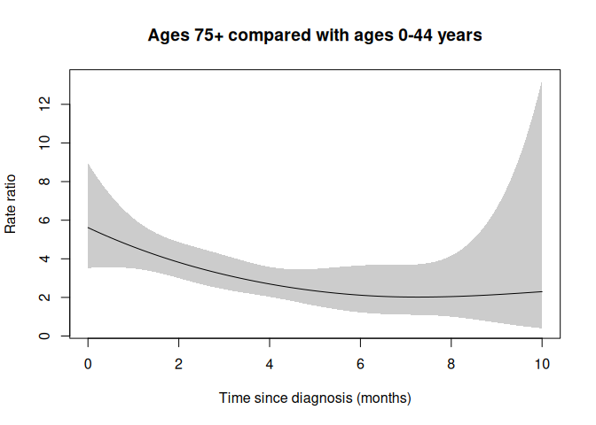

```r
library(splines) # ns
library(dplyr)   # mutate, group_by, summarise
library(rstpm2)  # predictnl
time.cuts <- seq(0,10,length=100)
delta <- diff(time.cuts)[1]
## split and collapse
melanoma2p8Split2 <- survSplit(Surv(trunc_yy,death_cancer)~., data=localised,
                               cut=time.cuts, end="tstop", start="tstart",
                               event="death_cancer") |>
    mutate(fu=cut(tstop,time.cuts),
           mid=time.cuts[unclass(fu)]+delta/2) |>
    group_by(mid,sex,year8594,agegrp) |>
    summarise(pt=sum(tstop-tstart), death_cancer=sum(death_cancer),
              .groups="keep") |>
    mutate(age75 = (agegrp=="75+")+0)
poisson2p8tvc <- glm(death_cancer ~ sex + year8594 + agegrp + ns(mid,df=3) +
                         age75:ns(mid,df=3) + offset(log(pt)),
                     data=melanoma2p8Split2, family=poisson)
newdata <- data.frame(mid=seq(0,max(time.cuts),length=100), year8594="Diagnosed 85-94",
                      sex="Male", agegrp="75+", age75=1, pt=1)
predictnl(poisson2p8tvc,
          fun=function(fit,newdata)
              predict(fit, newdata) -
              predict(fit, transform(newdata, agegrp='0-44', age75=0)),
          newdata=newdata) |>
    cbind(newdata) |>
    transform(pred=exp(fit),
              lower=exp(fit-1.96*se.fit),
              upper=exp(fit+1.96*se.fit)) |>
    with(plt(mid, pred, type="ribbon", xlab="Time since diagnosis (months)",
             ymin=lower, ymax=upper,
             ylab="Rate ratio", main="Ages 75+ compared with ages 0-44 years"))
```

```r
summary(poisson2p8tvc)
```

```
##
## Call:
## glm(formula = death_cancer ~ sex + year8594 + agegrp + ns(mid,
##     df = 3) + age75:ns(mid, df = 3) + offset(log(pt)), family = poisson,
##     data = melanoma2p8Split2)
##
## Coefficients:
##                         Estimate Std. Error z value Pr(>|z|)
## (Intercept)             -4.29223    0.14458 -29.688  < 2e-16 ***
## sexFemale               -0.52750    0.06541  -8.064 7.36e-16 ***
## year8594Diagnosed 85-94 -0.32668    0.06628  -4.929 8.28e-07 ***
## agegrp45-59              0.28753    0.09418   3.053 0.002265 **
## agegrp60-74              0.62943    0.09089   6.925 4.36e-12 ***
## agegrp75+                1.71564    0.23189   7.399 1.38e-13 ***
## ns(mid, df = 3)1        -0.67587    0.17890  -3.778 0.000158 ***
## ns(mid, df = 3)2         1.71393    0.32526   5.269 1.37e-07 ***
## ns(mid, df = 3)3        -0.92248    0.20709  -4.454 8.41e-06 ***
## ns(mid, df = 3)1:age75  -0.93947    0.56050  -1.676 0.093713 .
## ns(mid, df = 3)2:age75  -1.51156    0.80963  -1.867 0.061907 .
## ns(mid, df = 3)3:age75  -0.52292    0.85343  -0.613 0.540055
## ---
## Signif. codes:  0 '***' 0.001 '**' 0.01 '*' 0.05 '.' 0.1 ' ' 1
##
## (Dispersion parameter for poisson family taken to be 1)
##
##     Null deviance: 1841.4  on 1583  degrees of freedom
## Residual deviance: 1460.0  on 1572  degrees of freedom
## AIC: 2893.5
##
## Number of Fisher Scoring iterations: 6
```

```r
newdata <- expand.grid(mid=c(0.5,2), year8594="Diagnosed 85-94",
                       sex="Male", agegrp=levels(localised$agegrp), pt=1) |>
    transform(age75=(agegrp=="75+")+0)
predictnl(poisson2p8tvc,
          fun=function(fit,newdata)
              predict(fit, newdata) -
              predict(fit, transform(newdata, agegrp='0-44', age75=0)),
          newdata=newdata) |>
    cbind(newdata) |>
    transform(pred=exp(fit),
              lower=exp(fit-1.96*se.fit),
              upper=exp(fit+1.96*se.fit)) |>
    subset(select=c(agegrp, mid, pred, lower, upper))
```

```
##   agegrp mid     pred    lower    upper
## 1   0-44 0.5 1.000000 1.000000 1.000000
## 2   0-44 2.0 1.000000 1.000000 1.000000
## 3  45-59 0.5 1.333128 1.108426 1.603381
## 4  45-59 2.0 1.333128 1.108426 1.603381
## 5  60-74 0.5 1.876535 1.570315 2.242468
## 6  60-74 2.0 1.876535 1.570315 2.242468
## 7    75+ 0.5 5.091943 3.557290 7.288662
## 8    75+ 2.0 3.817641 2.996414 4.863940
```